# Final Report

Comprehensive report

Pragyanta Dhal  
2022-05-12

### Introduction:

Students’ academic performance is affected by several factors which include students’ learning skills, parental background, peer influence, teachers’ quality, learning infrastructure among others. Many teachers believe that analyzing student testing data can boost performance, but research suggests otherwise. Analyzing this data set can give us insights, correlations between different factors responsible and affecting a student’s performance.

### Load libraries

```r
library(readr)
library(dplyr)
library(ggplot2)
library(tidyr)
```

### Read CSV data

```r
student <- read_csv("./data.csv")
```

The dataset is loaded using the read_csv(). It has 1000 rows and 8 columns. Columns are : gender, race/ethnicity, parental level of education, lunch, test preparation course, math score, reading score, writing score. Below is a glimpse of the dataset:

```r
str(student)
```

```
spec_tbl_df [1,000 × 8] (S3: spec_tbl_df/tbl_df/tbl/data.frame)
 $ gender                     : chr [1:1000] "female" "female" "female" "male" ...
 $ race/ethnicity             : chr [1:1000] "group B" "group C" "group B" "group A" ...
 $ parental level of education: chr [1:1000] "bachelor's degree" "some college" "master's degree" "associate's degree" ...
 $ lunch                      : chr [1:1000] "standard" "standard" "standard" "free/reduced" ...
 $ test preparation course    : chr [1:1000] "none" "completed" "none" "none" ...
 $ math score                 : num [1:1000] 72 69 90 47 76 71 88 40 64 38 ...
 $ reading score              : num [1:1000] 72 90 95 57 78 83 95 43 64 60 ...
 $ writing score              : num [1:1000] 74 88 93 44 75 78 92 39 67 50 ...
 - attr(*, "spec")=
  .. cols(
  ..   gender = col_character(),
  ..   `race/ethnicity` = col_character(),
  ..   `parental level of education` = col_character(),
  ..   lunch = col_character(),
  ..   `test preparation course` = col_character(),
  ..   `math score` = col_double(),
  ..   `reading score` = col_double(),
  ..   `writing score` = col_double()
  .. )
 - attr(*, "problems")=<externalptr>
```

### Data wrangling and cleaning

Check if the data contains missing values or NAs

```r
sapply(student, function(x) sum(is.na(x)))
```

```
                     gender              race/ethnicity
                          0                           0
parental level of education                       lunch
                          0                           0
    test preparation course                  math score
                          0                           0
              reading score               writing score
                          0                           0
```

### Renaming the columns for better understanding

```r
colnames(student)[2] <- "race_ethnicity_group"
colnames(student)[3] <- "parent_highest_education"
colnames(student)[5] <- "test_preparation_course"
colnames(student)[6] <- "math_marks"
colnames(student)[7] <- "reading_marks"
colnames(student)[8] <- "writing_marks"
```

### Converting few columns from character to factor

```r
student$gender <- as.factor(student$gender)
student$race_ethnicity_group <- as.factor(student$race_ethnicity_group)
student$lunch <- as.factor(student$lunch)
student$test_preparation_course <- as.factor(student$test_preparation_course)
```

### Creating new columns namely total and average score

```r
student$total_marks = student$math_marks  + student$reading_marks + student$writing_marks
student$mean_marks = round((student$total_marks)/3,2)
```

### Alloting grades as per the average score

```r
student <- student %>%
     mutate(grade = case_when(
         mean_marks >= 90 & mean_marks <= 100 ~ "A",
         mean_marks >= 80 & mean_marks < 90 ~ "B",
         mean_marks >= 70 & mean_marks < 80 ~ "C",
         mean_marks >= 60 & mean_marks < 70  ~ "D",
         mean_marks >= 50 & mean_marks < 60  ~ "E",
         mean_marks < 50 ~ "F"
     )%>% as.factor()
     )
```

### Defining the order of levels in parent’s highest education

```r
student$parent_highest_education <-
     student$parent_highest_education %>%
     factor(levels = c("some high school","high school", "some college" ,
                       "associate's degree","bachelor's degree", "master's degree")
     )
```

Lets have a look at our data again :

```r
str(student)
```

```
tibble [1,000 × 11] (S3: tbl_df/tbl/data.frame)
 $ gender                  : Factor w/ 2 levels "female","male": 1 1 1 2 2 1 1 2 2 1 ...
 $ race_ethnicity_group    : Factor w/ 5 levels "group A","group B",..: 2 3 2 1 3 2 2 2 4 2 ...
 $ parent_highest_education: Factor w/ 6 levels "some high school",..: 5 3 6 4 3 4 3 3 2 2 ...
 $ lunch                   : Factor w/ 2 levels "free/reduced",..: 2 2 2 1 2 2 2 1 1 1 ...
 $ test_preparation_course : Factor w/ 2 levels "completed","none": 2 1 2 2 2 2 1 2 1 2 ...
 $ math_marks              : num [1:1000] 72 69 90 47 76 71 88 40 64 38 ...
 $ reading_marks           : num [1:1000] 72 90 95 57 78 83 95 43 64 60 ...
 $ writing_marks           : num [1:1000] 74 88 93 44 75 78 92 39 67 50 ...
 $ total_marks             : num [1:1000] 218 247 278 148 229 232 275 122 195 148 ...
 $ mean_marks              : num [1:1000] 72.7 82.3 92.7 49.3 76.3 ...
 $ grade                   : Factor w/ 6 levels "A","B","C","D",..: 3 2 1 6 3 3 1 6 4 6 ...
```

```r
summary(student)
```

```
    gender    race_ethnicity_group       parent_highest_education
 female:518   group A: 89          some high school  :179
 male  :482   group B:190          high school       :196
              group C:319          some college      :226
              group D:262          associate's degree:222
              group E:140          bachelor's degree :118
                                   master's degree   : 59
          lunch     test_preparation_course   math_marks
 free/reduced:355   completed:358           Min.   :  0.00
 standard    :645   none     :642           1st Qu.: 57.00
                                            Median : 66.00
                                            Mean   : 66.09
                                            3rd Qu.: 77.00
                                            Max.   :100.00
 reading_marks    writing_marks     total_marks      mean_marks
 Min.   : 17.00   Min.   : 10.00   Min.   : 27.0   Min.   :  9.00
 1st Qu.: 59.00   1st Qu.: 57.75   1st Qu.:175.0   1st Qu.: 58.33
 Median : 70.00   Median : 69.00   Median :205.0   Median : 68.33
 Mean   : 69.17   Mean   : 68.05   Mean   :203.3   Mean   : 67.77
 3rd Qu.: 79.00   3rd Qu.: 79.00   3rd Qu.:233.0   3rd Qu.: 77.67
 Max.   :100.00   Max.   :100.00   Max.   :300.0   Max.   :100.00
 grade
 A: 52
 B:146
 C:261
 D:256
 E:182
 F:103
```

## Research Questions

1. Which gender performs better on an average?
2. How does the grade distribution looks like?
3. How is the performance of students who have completed the preparation course against those who have not?
4. How much does the parental highest education level impact their child’s performance?
5. How helpful are test preparation materials for the students given the educational level of parents.
6. What is the relationship between students having standard or free lunch with their marks received?

## Analyzing data before visualizations

I order to gain understanding of the data statistics and be familiar with the distributions of each variable in the data set.

### Descriptive statistics of numerical columns

Mean of the numeric columns:

```r
student %>%
    summarise_if(is.numeric, mean)
```

```
# A tibble: 1 × 5
  math_marks reading_marks writing_marks total_marks mean_marks
       <dbl>         <dbl>         <dbl>       <dbl>      <dbl>
1       66.1          69.2          68.1        203.       67.8
```

Median of the numeric columns:

```r
student %>%
    summarise_if(is.numeric, median)
```

```
# A tibble: 1 × 5
  math_marks reading_marks writing_marks total_marks mean_marks
       <dbl>         <dbl>         <dbl>       <dbl>      <dbl>
1         66            70            69         205       68.3
```

Standard deviation of the numeric columns:

```r
student %>%
    summarise_if(is.numeric, sd)
```

```
# A tibble: 1 × 5
  math_marks reading_marks writing_marks total_marks mean_marks
       <dbl>         <dbl>         <dbl>       <dbl>      <dbl>
1       15.2          14.6          15.2        42.8       14.3
```

### Descriptive statistics of categorical columns

Frequency of gender

```r
student %>%
     group_by(gender) %>%
     summarise(count = n())
```

```
# A tibble: 2 × 2
  gender count
  <fct>  <int>
1 female   518
2 male     482
```

Frequency of ethnicity group of students:

```r
student %>%
     group_by(race_ethnicity_group) %>%
     summarise(count = n())
```

```
# A tibble: 5 × 2
  race_ethnicity_group count
  <fct>                <int>
1 group A                 89
2 group B                190
3 group C                319
4 group D                262
5 group E                140
```

Frequency of the highest education obtained by parents:

```r
student %>%
     group_by(parent_highest_education) %>%
     summarise(count = n())
```

```
# A tibble: 6 × 2
  parent_highest_education count
  <fct>                    <int>
1 some high school           179
2 high school                196
3 some college               226
4 associate's degree         222
5 bachelor's degree          118
6 master's degree             59
```

Frequency of the type of lunch:

```r
student %>%
     group_by(lunch) %>%
     summarise(count = n())
```

```
# A tibble: 2 × 2
  lunch        count
  <fct>        <int>
1 free/reduced   355
2 standard       645
```

Frequency of the completion of course materials:

```r
student %>%
     group_by(test_preparation_course) %>%
     summarise(count = n())
```

```
# A tibble: 2 × 2
  test_preparation_course count
  <fct>                   <int>
1 completed                 358
2 none                      642
```

### Descriptive statistics of relevant grouping

Calculating mean, median and Standard deviation of the marks obtained in Maths, grouped by gender:

```r
student %>%
     group_by(gender) %>%
     summarise(gender_count = n(), mean_math_marks = mean(math_marks), median_math_marks = median(math_marks), sd_math_marks = sd(math_marks))
```

```
# A tibble: 2 × 5
  gender gender_count mean_math_marks median_math_marks sd_math_marks
  <fct>         <int>           <dbl>             <dbl>         <dbl>
1 female          518            63.6                65          15.5
2 male            482            68.7                69          14.4
```

Calculating mean, median and Standard deviation of the marks obtained in Maths, grouped by ethnic group:

```r
student %>%
     group_by(race_ethnicity_group) %>%
     summarise(race_ethnicity_group_count = n(), mean_math_marks = mean(math_marks), median_math_marks = median(math_marks), sd_math_marks = sd(math_marks))
```

```
# A tibble: 5 × 5
  race_ethnicity_gr… race_ethnicity_… mean_math_marks median_math_mar…
  <fct>                         <int>           <dbl>            <dbl>
1 group A                          89            61.6             61
2 group B                         190            63.5             63
3 group C                         319            64.5             65
4 group D                         262            67.4             69
5 group E                         140            73.8             74.5
# … with 1 more variable: sd_math_marks <dbl>
```

Calculating mean, median and Standard deviation of the marks obtained in Maths, grouped by gender and completion of test courses:

```r
student %>%
  group_by(gender, test_preparation_course) %>%
  summarise(count_gender= n(), mean_math_marks = mean(math_marks), median_math_marks = median(math_marks), sd_math_marks = sd(math_marks))
```

```
# A tibble: 4 × 6
# Groups:   gender [2]
  gender test_preparation_course count_gender mean_math_marks
  <fct>  <fct>                          <int>           <dbl>
1 female completed                        184            67.2
2 female none                             334            61.7
3 male   completed                        174            72.3
4 male   none                             308            66.7
# … with 2 more variables: median_math_marks <dbl>,
#   sd_math_marks <dbl>
```

# Moving on to Visualizations

### 1. Overall grade distribution

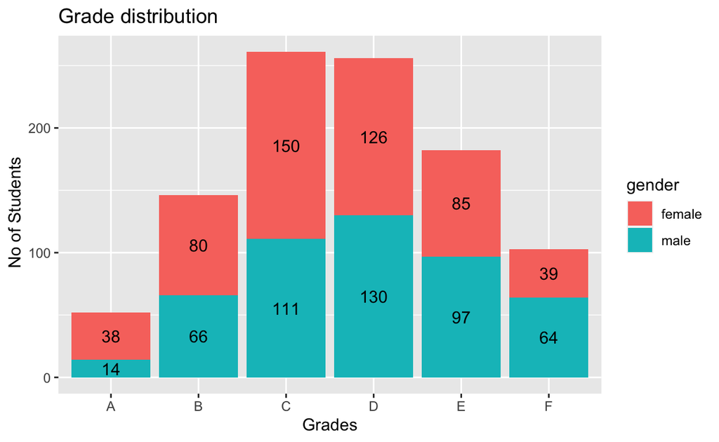

```r
ggplot(student, aes( x= grade, fill = gender)) +
    geom_bar() +
    geom_text(stat="count" ,aes(label=..count..), position = position_stack( vjust = 0.5))+
    labs(title ="Grade distribution", x ="Grades", y = " No of Students")
```

**Observation** Majority of the students obtained grades C & D, which are almost equally spread across both the genders - male and female. There are more female students who have secured grade A, whereas more male students have failed the courses and secured grade F.

### 2. Reading Marks vs Writing Marks

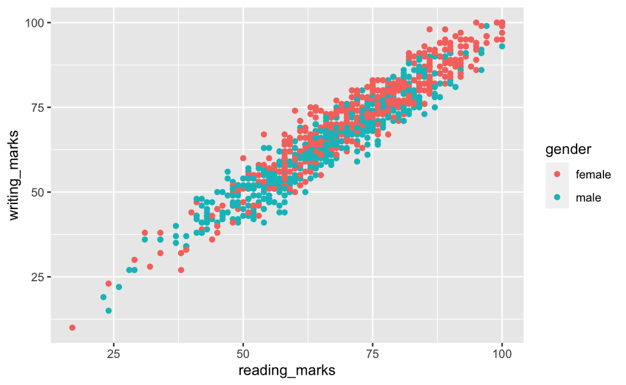

```r
ggplot(student,
        aes(x = reading_marks,
            y = writing_marks, color=gender)) +
     geom_point()
```

**Observation** It is observed that students who perform well in reading performed well in writing as well.

### 3.Plotting uncertainty in total score estimate by ethnic group

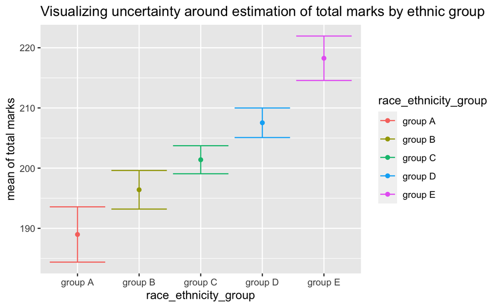

```r
student %>%
     group_by(race_ethnicity_group) %>%
     summarize(freq = n(),
               mean = mean(total_marks),
               sd = sd(total_marks),
               se = sd / sqrt(freq)) %>%
     ggplot(aes(x = race_ethnicity_group,
                y = mean,
                color = race_ethnicity_group)) +
     geom_errorbar(aes(ymin = mean - se,
                       ymax = mean + se)) +
     geom_point() + labs(title = "Visualizing uncertainty around estimation of total marks by ethnic group", y = "mean of total marks")
```

**Observation** It is observed that students who belong to ethnic group E performed significantly better than other students.

### 4. Scores for Free/Reduced and Standard Lunch by Ethnic Background

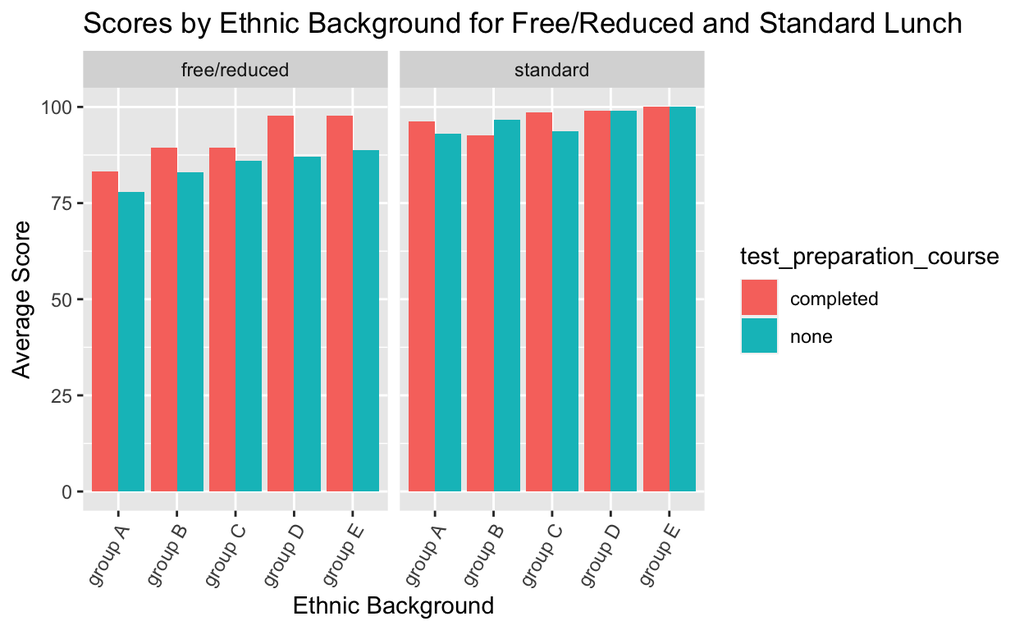

```r
 ggplot(student, aes(x= race_ethnicity_group, y = mean_marks, fill = test_preparation_course)) +
     geom_col(position = "dodge") +
     facet_wrap(~lunch)+
     labs(title="Scores by Ethnic Background for Free/Reduced and Standard Lunch",
          x ="Ethnic Background",
          y ="Average Score") +
     theme(axis.text.x = element_text(angle = 60, hjust = 1))
```

**Observation** - Majority of students who took the test preparation course performed better than those who did not. Whereas for students who took standard lunch and belong to group D and E, the test_preparation_course didn’t make any significant difference.

### 5. All Marks distribution across gender

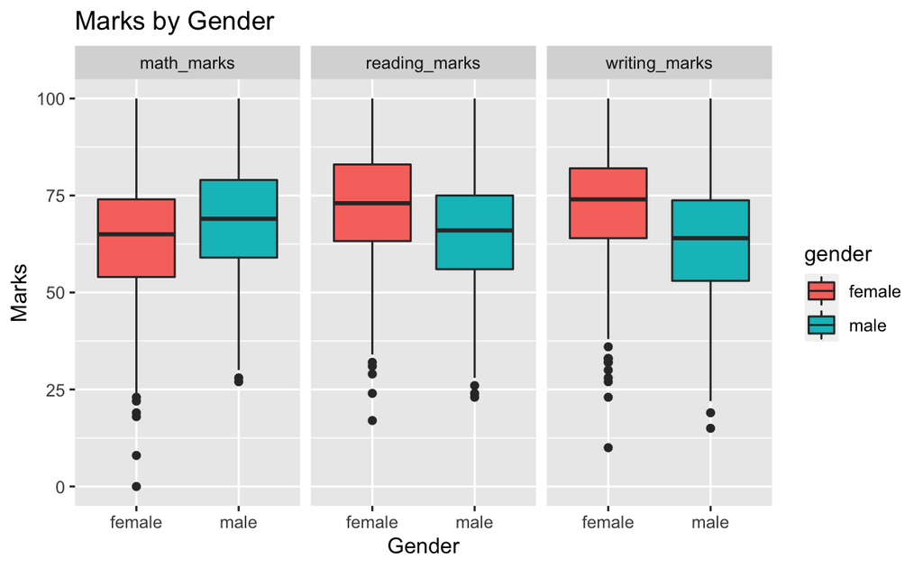

```r
student%>%
     select(gender, math_marks, reading_marks, writing_marks)%>%
     gather(key, value, -gender)%>%
     ggplot( aes(x=gender, y = value , fill = gender )) +
     geom_boxplot()+
     facet_grid(~key)+
     labs(title ="Marks by Gender", x= "Gender", y ="Marks")
```

**Observation** - Majority of Female students have performed better in reading and writing whereas majority of male students have performed better in maths.

### 6. Marks distribution and parental education level

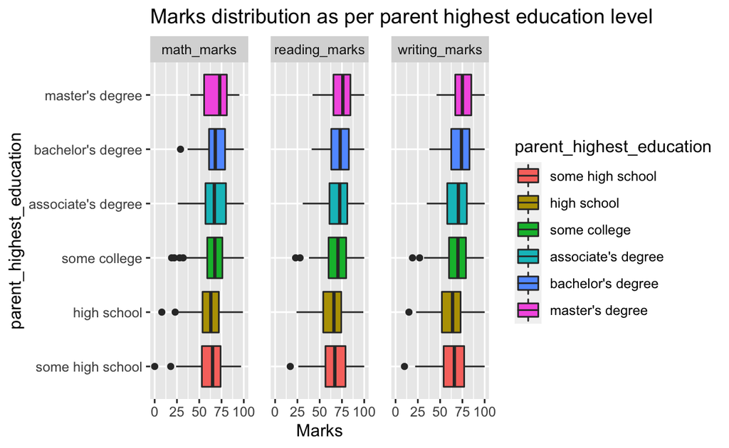

```r
 student%>%
     select(parent_highest_education, math_marks, reading_marks, writing_marks)%>%
     gather(key, value, -parent_highest_education)%>%
     ggplot( aes(x=parent_highest_education, y = value , fill = parent_highest_education )) +
     geom_boxplot()+
     facet_grid(~key)+
     labs(title ="Marks distribution as per parent highest education level", x= "parent_highest_education", y ="Marks") +
     theme(panel.spacing = unit(1, "lines")) +
     coord_flip()
```

**Observation** - It is quite clear from the plot that students whose parent’s highest education level is master’s degree performed better in reading, writing and maths.

### 7. Visualizing marks distribution of students according to their lunch type

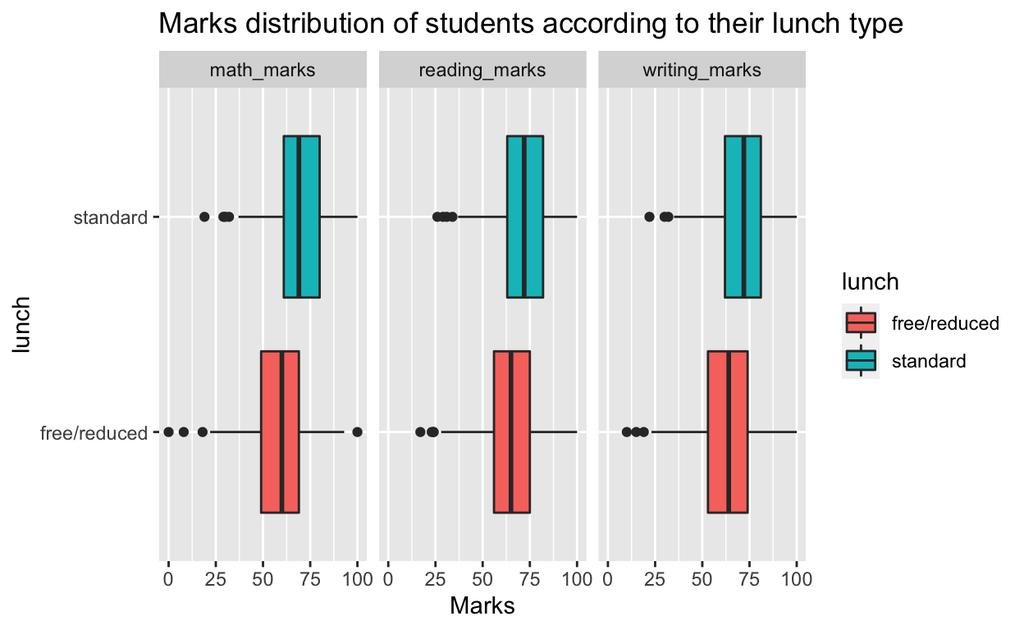

```r
student%>%
     select(lunch, math_marks, reading_marks, writing_marks)%>%
     gather(key, value, -lunch)%>%
     ggplot( aes(x=lunch, y = value , fill = lunch )) +
     geom_boxplot()+
     facet_grid(~key)+
     labs(title ="Marks distribution of students according to their lunch type", x= "lunch", y ="Marks")+
     coord_flip()
```

**Observation** It is clearly observed from the above plot that students with ‘standard’ lunch type perform better than students who receive free/reduced lunch. Hence, we can draw the inference that students with free/reduced lunch belong to lower middle class or low income families and perform lower than their counterparts.

### 8. Visualizing uncertainty around estimation of total marks

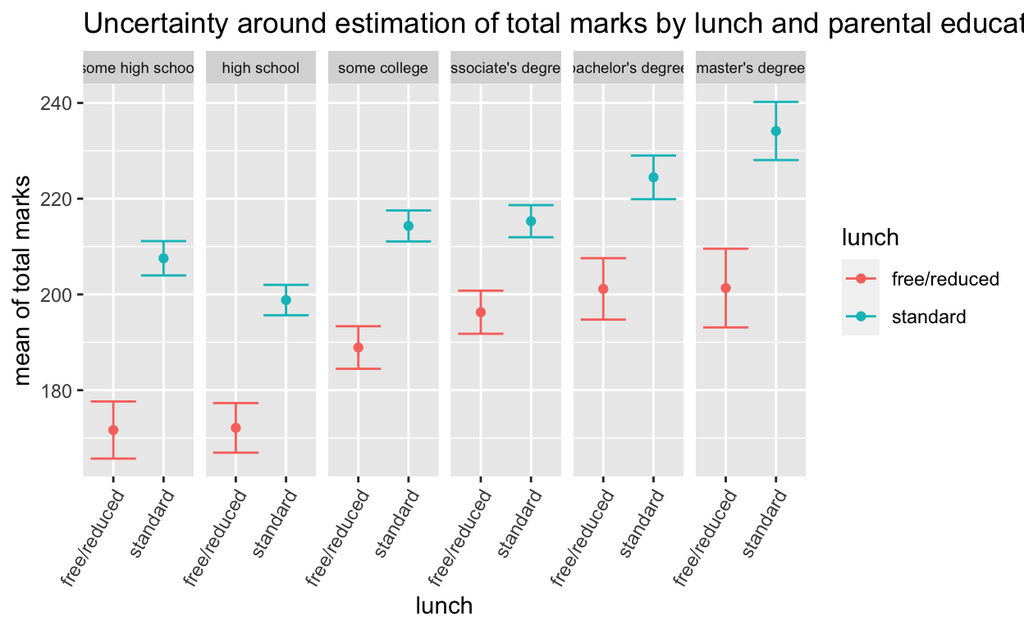

```r
student %>%
    group_by(lunch, parent_highest_education) %>%
    summarize(freq = n(),
              mean = mean(total_marks),
              sd = sd(total_marks),
              se = sd / sqrt(freq)) %>%
    ggplot(aes(x = lunch,
               y = mean,
               color = lunch)) +
    geom_errorbar(aes(ymin = mean - se,
                      ymax = mean + se)) +
    geom_point() + labs(title = "Uncertainty around estimation of total marks by lunch and parental education", y = "mean of total marks") +
    facet_grid(cols = vars(parent_highest_education)) +
    theme(axis.text.x = element_text(angle = 60, hjust = 1), strip.text = element_text(size=7))
```

**Observation** - It is quite evident from the plot that students who receive free/reduced lunch and whose parental educational level is “some high school” scored very low marks whereas the students who receive standard lunch and whose parents have master’s degree scored the highest marks.

### 9. Visualizing total marks for different parental levels of schooling depending on completion of the Test Preparation Course

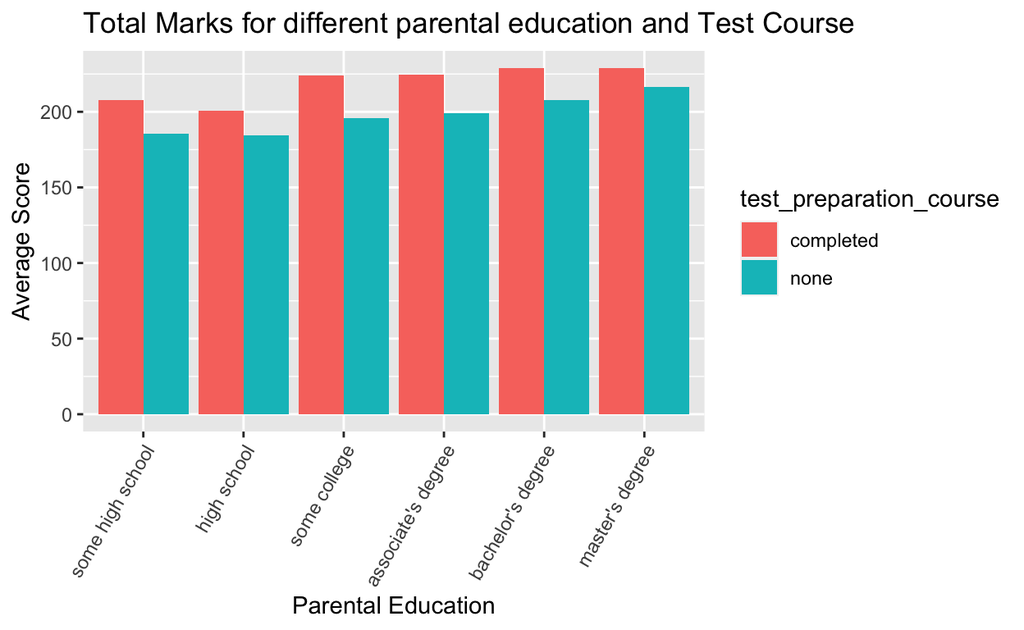

```r
student %>%
    group_by(parent_highest_education, test_preparation_course) %>%
    summarize(freq = n(),
              mean = mean(total_marks),
              sd = sd(total_marks),
              se = sd / sqrt(freq)) %>%
    ggplot(aes(x=parent_highest_education, y=mean, fill=test_preparation_course)) +
     geom_bar(position="dodge", stat="identity") +
     labs(title = "Total Marks for different parental education and Test Course", x='Parental Education', y="Average Score") + theme(axis.text.x = element_text(angle = 60, hjust = 1))
```

### Conclusion

Rigorous data analysis techniques were deployed on the dataset and the conclusions drawn are -

1. Majority of the students received a C or D grade.
2. Students who excelled in reading also excelled in writing.
3. The majority of female students outperformed the majority of male students in reading and writing, whereas the majority of male students outperformed the majority of female students in arithmetic.
4. Students from ethnic group E outperformed all other students substantially.
5. The majority of students who completed the exam preparation course outperformed those who did not. The test preparation course had no significant effect on students who ate standard lunch and were in groups D and E.
6. Students whose parents with a master’s degree did better in reading, writing, and math.
7. Students from low-income families with parents who have completed “some high school” had the lowest total marks, while students from middle-class families with parents who have completed a master’s degree received the highest total marks.

### Reflection

Throughout the duration of the project, I was exposed to numerous challenges. These challenges seemed difficult at first but eventually were easy to grasp, thanks to the tutorials provided. I picked a dataset that I as a student felt closely related to. So, this dataset housing performance of students across exams seemed like a natural fit. It didn’t take much time to familiarize myself with the columns of the dataset although I found a few column names to be ambiguous. Starting with the data wrangling stage, I was able to apply most of the techniques that includes checking for non-available (NA) values, renaming ambiguous columns as well as adding new columns along the way for better analysis.

Afterwards, I applied certain descriptive statistical measures on the continuous and categorical columns. It gave me a rough idea of the performance of the students which gave way to a few potential research questions. Post this stage, I selected few continuous and categorical columns and performed univariate and bivariate analysis. Afterwards, I refined these analysis and proceeded with multivariate analysis by applying techniques like grouping and faceting. At this point, I was able to answer almost all my research questions. I could also realize that there are a very few questions I would have liked to analyze but can’t answer due to the lack of information in the dataset. I wanted to analyze the number of hours spent in test_preparatory_course so that I could extrapolate the relationship between the number of hours dedicated by students and the marks they received.

Lastly, I compiled all my work, formatted it so that they appear aesthetically attractive and user friendly. Overall, it was a memorable journey filled with a lot of challenges as well as learnings along the way. One of the most challenging work was to shortlist the key features from the dataset and present it in a user-friendly so that a user shouldn’t feel overwhelmed by an abundance of information.

### Bibliography

1. http://roycekimmons.com/tools/generated_data/exams
2. Textbook : R for Data Science (https://r4ds.had.co.nz/index.html)